# Gradientes ambientales y composición florística en el municipio de Azua

Desacoplando la señal ecológica del sesgo de registro

Heriberto Matos

2026-09-27

# Introducción

# Introducción

- **Premisa teórica:** Gradientes ambientales actúan como **filtros fisiológicos** que estructuran el recambio vegetal (Legendre and Legendre 2012).
- **Escenario regional:** Valle de Azua bajo fuerte **déficit hídrico** por **sombra pluviométrica** (Cordillera Central y Sierra Martín García).
- **Fisonomía vegetal:** Dominancia de **bosque seco subtropical** y **matorral xerofítico**, en transición abrupta con laderas premontañosas.
- **Problemática de datos:** Repositorios abiertos (**GBIF**) con severas **asimetrías espaciales** por colectas oportunistas.
- **Riesgo analítico:** Confundir la **accesibilidad vial** con centros intrínsecos de biodiversidad.

# Marco y problemática

- **Premisa biogeográfica:** Gradientes físicos estructuran el recambio y ensamblaje vegetal.
- **Contexto regional:** Planicie semiárida de Azua bajo sombra pluviométrica vs. ecotonos premontañosos.
- **Conflicto central:** Repositorios abiertos (**GBIF**) presentan severo **sesgo espacial oportunista**.
- **Riesgo analítico:** Confundir accesibilidad vial con centros reales de riqueza biológica.

# Preguntas e hipótesis

- **Pregunta clave:** ¿Cuánto explica el ambiente el recambio florístico vs. el sesgo de registro?
- **Hipótesis 1 (Composición):** Recambio condicionado por la **cobertura leñosa** y la **aridez térmica**.
- **Hipótesis 2 (Riqueza):** Riqueza observada **sobredeterminada por el esfuerzo de colecta** acumulado.

# Materiales y métodos

# Datos y preprocesamiento

- **Área territorial:** Municipio de Azua (`050201_azua`).
- **Unidad espacial:** Malla hexagonal discreta **H3 resolución 7** (~5.2 km² por celda).
- **Registros botánicos:** Presencias primarias de flora vascular (GBIF).
- **Filtrado comunitario:** Celdas con $\ge$ 3 especies y taxones en $\ge$ 2 hexágonos.
- **Matriz resultante:** 29 hexágonos y 126 especies vasculares.

# Métodos estadísticos

- **NMDS (`vegan::metaMDS`):**
  - Distancia **Jaccard** binaria ($k = 2$) (Legendre and Legendre 2012).
  - Ordenación no lineal de recambio taxonómico.
- **Ajuste ambiental (`envfit`):**
  - Vectores físicos con 999 permutaciones (Borcard, Gillet, and Legendre 2018).
- **GLM (Riqueza observada):**
  - Familia **cuasi-Poisson** por sobredispersión ($\phi > 1.5$) (Venables and Ripley 2002).
  - Predictor covariable: $\ln(\text{registros} + 1)$.

# Evaluación de hábitats y dispersión

- **Exploración categórica:** Asimetría muestral en bosque seco y matorral xerofítico.
- **Riesgo estadístico:** Desbalance y dispersión multivariada heterogénea (`betadisper`).
- **Decisión metodológica:** Descarte de **PERMANOVA** (`adonis2`) (Anderson 2001).
- **Criterio analítico:** Enfoque exclusivo en gradientes continuos sobre el NMDS.

# Resultados

# Ordenación comunitaria: NMDS

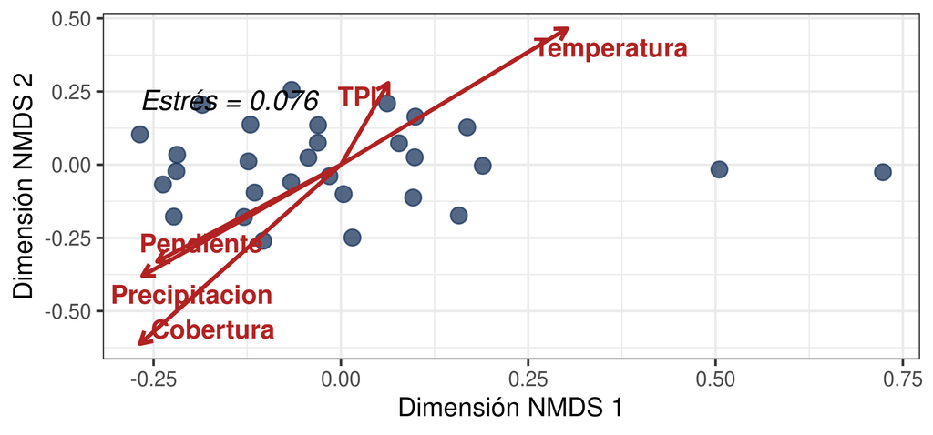

# Ajuste de vectores ambientales (envfit)

|  | Variable | r² | p-valor |
| --- | --- | --- | --- |
| Cobertura | Cobertura | 0.446 | 0.001 |
| Temperatura | Temperatura | 0.307 | 0.008 |
| Precipitacion | Precipitacion | 0.214 | 0.029 |
| Pendiente | Pendiente | 0.170 | 0.080 |
| TPI | TPI | 0.082 | 0.332 |

# Sesgo de muestreo vs. riqueza

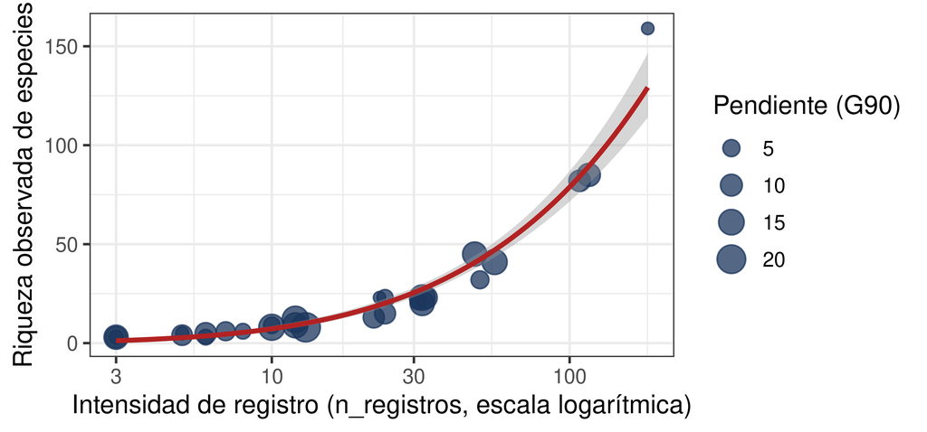

- **Efecto primario:** Intensidad de colecta dominante ($\beta = 1.037$, $p < 0.001$).
- **Concentración:** Mayor riqueza asociada a proximidad vial (carretera Sánchez) y centros urbanos.

# Discusión

# Señal ecológica vs. sesgo

- **Beta diversidad real:** Jaccard y NMDS capturan la transición entre el matorral xerofítico y el bosque seco transicional.
- **Alfa diversidad distorsionada:** Riqueza condicionada a la cercanía con vías de acceso principales.
- **Escala H3 (Res. 7):** Promedia microtopografía y suaviza contrastes locales de suelo.
- **Implicación:** Necesidad de modelar explícitamente el esfuerzo antes de emitir zonificaciones de conservación.

# Conclusiones

# Conclusiones principales

- **Composición florística:** Determinada por gradientes de **cobertura leñosa** y **estrés térmico**.
- **Riqueza de especies:** Sobredeterminada por el **sesgo de muestreo oportunista** ($\beta = 1.037$).
- **Validez metodológica:** Desacople exitoso entre señal comunitaria y artefacto de colecta.
- **Recomendación:** Desaconsejado el uso directo de GBIF sin corrección de esfuerzo para la toma de decisiones.

# Auditoría de IA y reproducibilidad

- **Herramienta:** Asistencia de Google Gemini en código y modelado.
- **Control humano sobre errores de la IA:**
  1. *Esquema espacial:* Corrección de `G90.Slope` y `G90.Topographic.Position.Index` (se asumió `Elevacion`).
  2. *Filtrado destructivo:* Rechazo de umbral rígido que vació la matriz ($0 \times 0$, error `'dist' cannot be all zero`).
  3. *Etiquetas en knitr:* Saneamiento manual de colisiones en nombres de chunks.
- **Reproducibilidad:** Entorno R v4.4.0 (`Ubuntu 22.04 LTS`) con librerías fijadas.

# Literatura citada

# Referencias

Anderson, Marti J. 2001. “A New Method for Non-Parametric Multivariate Analysis of Variance.” *Austral Ecology* 26 (1): 32–46. https://doi.org/10.1111/j.1442-9993.2001.01070.pp.x.

Borcard, Daniel, François Gillet, and Pierre Legendre. 2018. *Numerical Ecology with r*. 2nd ed. Springer. https://doi.org/10.1007/978-3-319-71404-2.

Legendre, Pierre, and Louis Legendre. 2012. *Numerical Ecology*. 3rd ed. Elsevier.

Venables, William N., and Brian D. Ripley. 2002. *Modern Applied Statistics with s*. 4th ed. New York: Springer. https://doi.org/10.1007/978-0-387-21706-2.